# Abalone Rings Perdiction

Tadros Salama

2021-05-09

### How well can we predict the number of rings on a abalone shell?

**Data**

```r
library(AppliedPredictiveModeling)
data(abalone)
```

## Summary STATS

|  | Type | LongestShell | Diameter | Height | WholeWeight | ShuckedWeight | VisceraWeight | ShellWeight | Rings |
| --- | --- | --- | --- | --- | --- | --- | --- | --- | --- |
|  | F:1307 | Min. :0.075 | Min. :0.0550 | Min. :0.0000 | Min. :0.0020 | Min. :0.0010 | Min. :0.0005 | Min. :0.0015 | Min. : 1.000 |
|  | I:1342 | 1st Qu.:0.450 | 1st Qu.:0.3500 | 1st Qu.:0.1150 | 1st Qu.:0.4415 | 1st Qu.:0.1860 | 1st Qu.:0.0935 | 1st Qu.:0.1300 | 1st Qu.: 8.000 |
|  | M:1528 | Median :0.545 | Median :0.4250 | Median :0.1400 | Median :0.7995 | Median :0.3360 | Median :0.1710 | Median :0.2340 | Median : 9.000 |
|  | NA | Mean :0.524 | Mean :0.4079 | Mean :0.1395 | Mean :0.8287 | Mean :0.3594 | Mean :0.1806 | Mean :0.2388 | Mean : 9.934 |
|  | NA | 3rd Qu.:0.615 | 3rd Qu.:0.4800 | 3rd Qu.:0.1650 | 3rd Qu.:1.1530 | 3rd Qu.:0.5020 | 3rd Qu.:0.2530 | 3rd Qu.:0.3290 | 3rd Qu.:11.000 |
|  | NA | Max. :0.815 | Max. :0.6500 | Max. :1.1300 | Max. :2.8255 | Max. :1.4880 | Max. :0.7600 | Max. :1.0050 | Max. :29.000 |

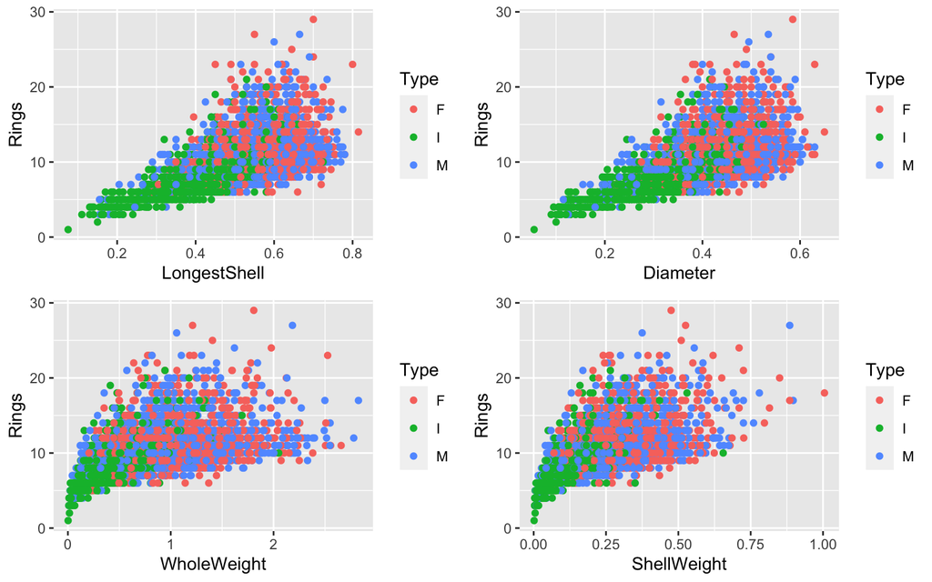

- Variables `LongestShell` and `Diameter` appears to have the strongest relationship with the number of rings on an abalone shell. The different weight measurements also showed a positive relationship with number of rings. Gender does not appear to have an effect on the number of rings, but age does.

Spliting data into 70% `train` & 30% `test`

```r
set.seed(123)
n <- nrow(abalone)
train_index <- sample(1:n, round(0.7 * n))
train <- abalone[train_index, ]
test <- abalone[-train_index, ]
```

## Multiple Linear Regression

```r
lm1 <- lm(Rings ~ ., train)
summary(lm1)
```

```
##
## Call:
## lm(formula = Rings ~ ., data = train)
##
## Residuals:
##    Min     1Q Median     3Q    Max
## -8.444 -1.313 -0.336  0.880 14.136
##
## Coefficients:
##               Estimate Std. Error t value Pr(>|t|)
## (Intercept)     3.0932     0.3492   8.858  < 2e-16 ***
## TypeI          -0.7255     0.1223  -5.931 3.37e-09 ***
## TypeM           0.1159     0.0993   1.167 0.243116
## LongestShell   -0.7745     2.1287  -0.364 0.716018
## Diameter        9.8634     2.6414   3.734 0.000192 ***
## Height         25.1272     2.7536   9.125  < 2e-16 ***
## WholeWeight     9.0528     0.8657  10.457  < 2e-16 ***
## ShuckedWeight -19.9145     0.9915 -20.086  < 2e-16 ***
## VisceraWeight -11.8409     1.5667  -7.558 5.46e-14 ***
## ShellWeight     7.1323     1.3232   5.390 7.60e-08 ***
## ---
## Signif. codes:  0 '***' 0.001 '**' 0.01 '*' 0.05 '.' 0.1 ' ' 1
##
## Residual standard error: 2.186 on 2914 degrees of freedom
## Multiple R-squared:  0.5442, Adjusted R-squared:  0.5428
## F-statistic: 386.6 on 9 and 2914 DF,  p-value: < 2.2e-16
```

- decent $R^2$ score. variables `longestShell` and gender, `TypeM` not so useful.

## Regression Tree

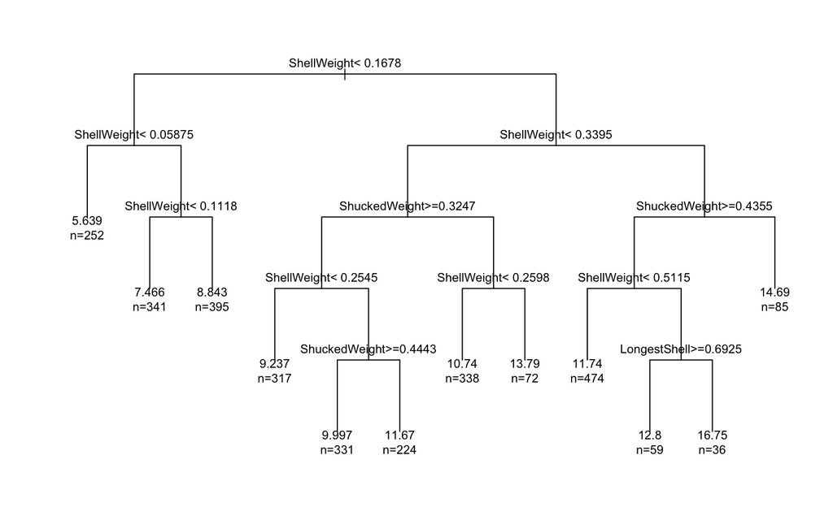

```r
t1 <- rpart(Rings ~ ., data=train, method = 'anova')
par(cex=0.7, xpd=NA)
plot(t1, uniform = TRUE)
text(t1, use.n = T)
```

## Random Forest

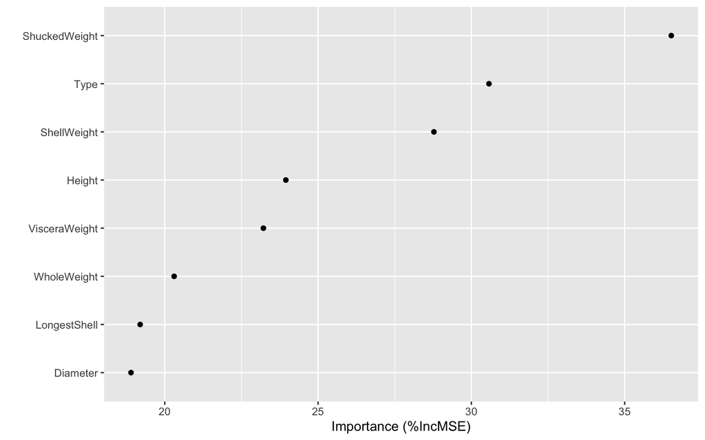

```r
rf1 <- randomForest(Rings ~.,train, importance= TRUE)
vip(rf1, num_features = 20, geom = "point", include_type = TRUE)
```

## Results

```r
RMSE <- function(y, y_hat) { sqrt(mean((y - y_hat)^2))
}
```

```r
pred_lm <- predict(lm1, newdata = test)
pred_t <- predict(t1, newdata = test)
pred_rf <- predict(rf1, newdata = test)

lm_score <- RMSE(test$Rings, pred_lm)
t_score <- RMSE(test$Rings, pred_t)
rf_score <- RMSE(test$Rings, pred_rf)
```

- The Random Forests model, `rf1` had the best predictive performance. When applied to the test data, it’s predictions were on average 2.1 rings off from the correct number of rings on a abalone shell.
- The Regression Tree model, `t1` had the worst predictive performance. On average, it’s predictions were 2.4 rings off from the correct number of shells.

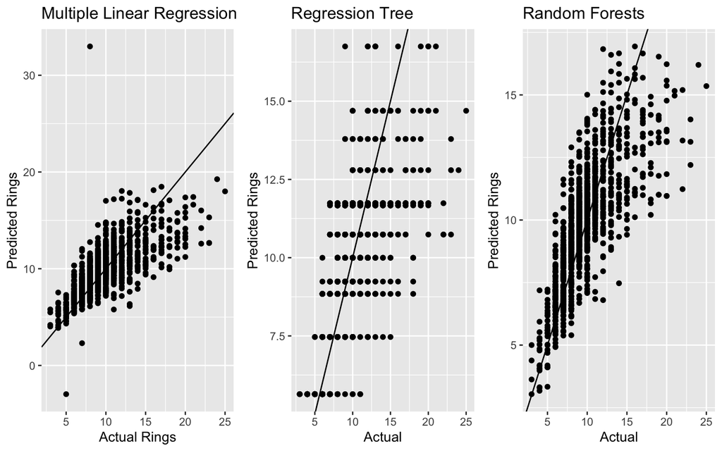

```r
pred_df <- data.frame(
  Actual = test$Rings,
  mlm = pred_lm,
  regtree = pred_t,
  rf = pred_rf
)

plot_lm <- ggplot(pred_df, aes(Actual, mlm)) +
  geom_point() +
  geom_abline(intercept = 0, slope = 1) +
  xlab("Actual Rings") + ylab("Predicted Rings") +
  ggtitle('Multiple Linear Regression')

plot_rt <- ggplot(pred_df, aes(Actual, regtree)) +
  geom_point() +
  geom_abline(intercept = 0, slope = 1) +
  ylab("Predicted Rings") +
  ggtitle('Regression Tree')

plot_rf <- ggplot(pred_df, aes(Actual, rf)) +
  geom_point() +
  geom_abline(intercept = 0, slope = 1) +
  ylab("Predicted Rings") +
  ggtitle('Random Forests')

grid.arrange(plot_lm, plot_rt, plot_rf, ncol=3, nrow =1)
```

- The Regression Tree plot of predicted vs actual values looks different from the other two models, the points are distributed horizontally across the x-axis. This is because the algorithm segments the data into regions, and for every observation in that region, it makes a predictions based on the training data that fell in those regions.